# 重賞レース予測レポート【毎時自動更新中】

作成日時: 2025/10/05 13:04:48

☞ [マニュアル(pdf)](https://ryutoro-galois.github.io/keiba-predictor/manual/manual.pdf)

☞ 過去5年の同一レース結果: [2024年](https://ryutoro-galois.github.io/keiba-predictor/report/PredResult_2024y_raceDate_20241005_20241006.html), [2023年](https://ryutoro-galois.github.io/keiba-predictor/report/PredResult_2023y_raceDate_20231007_20231009.html), [2022年](https://ryutoro-galois.github.io/keiba-predictor/report/PredResult_2022y_raceDate_20221008_20221010.html), [2021年](https://ryutoro-galois.github.io/keiba-predictor/report/PredResult_2021y_raceDate_20211009_20211010.html), [2020年](https://ryutoro-galois.github.io/keiba-predictor/report/PredResult_2020y_raceDate_20201010_20201011.html)

☞ 過去4週間の別レース結果: [1週前(9/27-28)](https://ryutoro-galois.github.io/keiba-predictor/report/PredResult_2025y_raceDate_20250927_20250928.html), [2週前(9/20-21)](https://ryutoro-galois.github.io/keiba-predictor/report/PredResult_2025y_raceDate_20250920_20250921.html), [3週前(9/13-15)](https://ryutoro-galois.github.io/keiba-predictor/report/PredResult_2025y_raceDate_20250913_20250915.html), [4週前(9/6-7)](https://ryutoro-galois.github.io/keiba-predictor/report/PredResult_2025y_raceDate_20250906_20250907.html)

☞ netkeiba: [毎日王冠(GⅡ)](https://race.netkeiba.com/race/shutuba.html?race_id=202505040211&rf=race_list), [京都大賞典(GⅡ)](https://race.netkeiba.com/race/shutuba.html?race_id=202508030211&rf=race_list)

## 0. 推し馬予測 (AI予測)

### 【毎日王冠(GⅡ) 2025/10/05(日)】

- 本命(◎): 1-3着内確率(勝負強さ)が1位の馬
- 対抗(◯): 1-3着内確率が2-N位(20%程度以上)の中で予測タイムが最も速い馬
- 3番手(▲): 1-3着内確率が2-N位(20%程度以上)のでダークホース確率が最も高い馬
- 穴: ダークホース確率が上位1-M位(40%程度以上)の中で1-3着内確率が最も高い馬

| 推し馬 | 枠番 | 馬番 | 人気 | オッズ | 馬名 | 騎手 | 調教師 | 予測タイム(sec) | 1_順位 | 1-3着内確率(%) | 2_順位 | ﾀﾞｰｸﾎｰｽ確率(%) | 3_順位 |
| --- | --- | --- | --- | --- | --- | --- | --- | --- | --- | --- | --- | --- | --- |
| 本命(◎) | 6 | 6 | 2 | 4.1 | チェルヴィニア | 戸崎圭太 | 木村哲也 | 111.0 | 6 | 35.1 | 1 | 1.2 | 9 |
| 対抗(◯) | 8 | 10 | 1 | 2.5 | サトノシャイニング | 武豊 | 杉山晴紀 | 104.5 | 1 | 22.5 | 3 | 0.6 | 11 |
| 3番手(▲) | 7 | 9 | 5 | 7.6 | レーベンスティール | 津村明秀 | 田中博康 | 113.0 | 7 | 22.1 | 4 | 2.4 | 6 |
| 穴 | 5 | 5 | 10 | 48.9 | ジェイパームス | 佐々木大輔 | 堀宣行 | 108.0 | 2 | 7.3 | 7 | 41.8 | 3 |

### 【京都大賞典(GⅡ) 2025/10/05(日)】

- 本命(◎): 1-3着内確率(勝負強さ)が1位の馬
- 対抗(◯): 1-3着内確率が2-N位(20%程度以上)の中で予測タイムが最も速い馬
- 3番手(▲): 1-3着内確率が2-N位(20%程度以上)のでダークホース確率が最も高い馬
- 穴: ダークホース確率が上位1-M位(40%程度以上)の中で1-3着内確率が最も高い馬

| 推し馬 | 枠番 | 馬番 | 人気 | オッズ | 馬名 | 騎手 | 調教師 | 予測タイム(sec) | 1_順位 | 1-3着内確率(%) | 2_順位 | ﾀﾞｰｸﾎｰｽ確率(%) | 3_順位 |
| --- | --- | --- | --- | --- | --- | --- | --- | --- | --- | --- | --- | --- | --- |
| 本命(◎) | 4 | 7 | 2 | 6.0 | ドゥレッツァ | 横山武史 | 尾関知人 | 143.5 | 5 | 43.3 | 1 | 0.5 | 17 |
| 対抗(◯) | 2 | 3 | 5 | 8.7 | ディープモンスター | 浜中俊 | 池江泰寿 | 146.1 | 6 | 27.7 | 2 | 0.7 | 14 |
| 穴 | 4 | 8 | 14 | 63.2 | ヴェルミセル | 鮫島克駿 | 吉村圭司 | 152.0 | 9 | 12.0 | 8 | 51.8 | 3 |

## 1. 予測チャート (タイム/勝負強さ)

### 【毎日王冠(GⅡ)】

2025/10/05(日), 05_東京, 芝左1800m

[interactive chart not shown]

### 【京都大賞典(GⅡ)】

2025/10/05(日), 08_京都, 芝右外2400m

[interactive chart not shown]

## 2. オッズモニタリング (毎時)

### 【毎日王冠】

[interactive chart not shown]

### 【京都大賞典】

[interactive chart not shown]

## 3. 出馬表

### 【毎日王冠 2025/10/05(日) 】

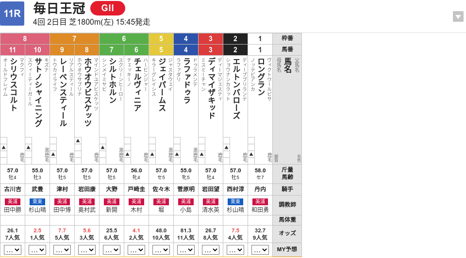

### 【京都大賞典 2025/10/05(日) 】

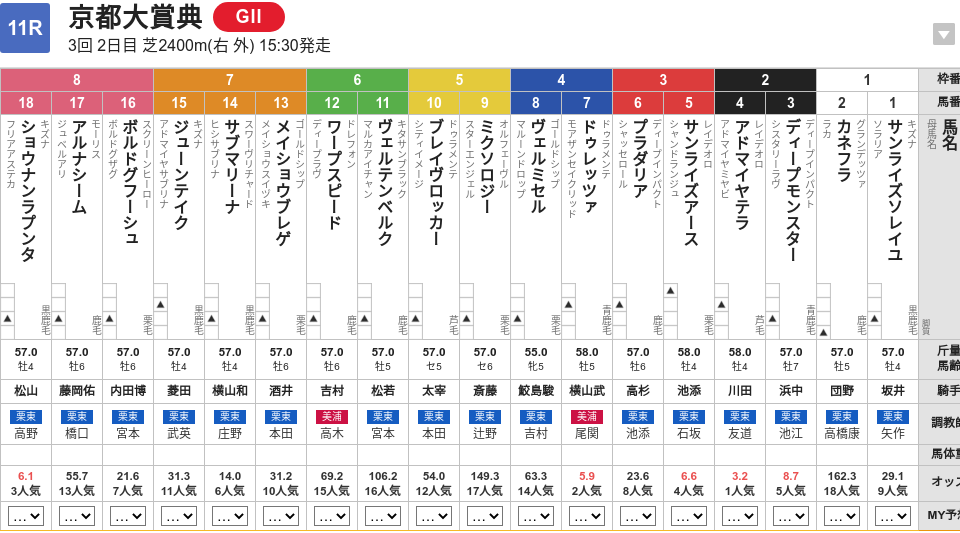

## 4. 単勝予測結果

### 【毎日王冠(GⅡ) 2025/10/05(日)】

| 枠番 | 馬番 | 人気 | オッズ | 馬名 | 騎手 | 調教師 | 予測タイム(sec) | 1_順位 | 1-3着内確率(%) | 2_順位 | ﾀﾞｰｸﾎｰｽ確率(%) | 3_順位 |
| --- | --- | --- | --- | --- | --- | --- | --- | --- | --- | --- | --- | --- |
| 1 | 1 | 9 | 33.5 | ロングラン | 丹内祐次 | 和田勇介 | 114.0 | 10 | 3.8 | 10 | 12.6 | 5 |
| 2 | 2 | 4 | 7.5 | エルトンバローズ | 西村淳也 | 杉山晴紀 | 113.1 | 8 | 15.7 | 5 | 1.8 | 8 |
| 3 | 3 | 8 | 26.2 | ディマイザキッド | 岩田望来 | 清水英克 | 110.6 | 4 | 6.6 | 9 | 43.1 | 2 |
| 4 | 4 | 11 | 80.7 | ラファドゥラ | 菅原明良 | 小島茂之 | 110.6 | 5 | 7.0 | 8 | 47.2 | 1 |
| 5 | 5 | 10 | 48.9 | ジェイパームス | 佐々木大輔 | 堀宣行 | 108.0 | 2 | 7.3 | 7 | 41.8 | 3 |
| 6 | 6 | 2 | 4.1 | チェルヴィニア | 戸崎圭太 | 木村哲也 | 111.0 | 6 | 35.1 | 1 | 1.2 | 9 |
| 6 | 7 | 7 | 25.5 | シルトホルン | 大野拓弥 | 新開幸一 | 113.5 | 9 | 2.4 | 11 | 19.2 | 4 |
| 7 | 8 | 3 | 5.6 | ホウオウビスケッツ | 岩田康誠 | 奥村武 | 114.1 | 11 | 26.0 | 2 | 1.1 | 10 |
| 7 | 9 | 5 | 7.6 | レーベンスティール | 津村明秀 | 田中博康 | 113.0 | 7 | 22.1 | 4 | 2.4 | 6 |
| 8 | 10 | 1 | 2.5 | サトノシャイニング | 武豊 | 杉山晴紀 | 104.5 | 1 | 22.5 | 3 | 0.6 | 11 |

[output cut: 1 more lines]

### 【京都大賞典(GⅡ) 2025/10/05(日)】

| 枠番 | 馬番 | 人気 | オッズ | 馬名 | 騎手 | 調教師 | 予測タイム(sec) | 1_順位 | 1-3着内確率(%) | 2_順位 | ﾀﾞｰｸﾎｰｽ確率(%) | 3_順位 |
| --- | --- | --- | --- | --- | --- | --- | --- | --- | --- | --- | --- | --- |
| 1 | 1 | 9 | 28.7 | サンライズソレイユ | 坂井瑠星 | 矢作芳人 | 153.1 | 15 | 13.2 | 7 | 1.7 | 11 |
| 1 | 2 | 18 | 157.5 | カネフラ | 団野大成 | 高橋康之 | 154.9 | 18 | 3.1 | 16 | 14.3 | 8 |
| 2 | 3 | 5 | 8.7 | ディープモンスター | 浜中俊 | 池江泰寿 | 146.1 | 6 | 27.7 | 2 | 0.7 | 14 |
| 2 | 4 | 1 | 3.1 | アドマイヤテラ | 川田将雅 | 友道康夫 | 142.9 | 2 | 16.1 | 6 | 0.5 | 15 |
| 3 | 5 | 4 | 6.8 | サンライズアース | 池添謙一 | 石坂公一 | 152.0 | 8 | 26.5 | 3 | 0.5 | 16 |
| 3 | 6 | 8 | 23.3 | プラダリア | 高杉吏麒 | 池添学 | 151.1 | 7 | 7.2 | 11 | 1.6 | 12 |
| 4 | 7 | 2 | 6.0 | ドゥレッツァ | 横山武史 | 尾関知人 | 143.5 | 5 | 43.3 | 1 | 0.5 | 17 |
| 4 | 8 | 14 | 63.2 | ヴェルミセル | 鮫島克駿 | 吉村圭司 | 152.0 | 9 | 12.0 | 8 | 51.8 | 3 |
| 5 | 9 | 17 | 150.6 | ミクソロジー | 斎藤新 | 辻野泰之 | 142.9 | 2 | 5.0 | 13 | 60.5 | 2 |
| 5 | 10 | 12 | 52.5 | ブレイヴロッカー | 太宰啓介 | 本田優 | 153.5 | 17 | 2.5 | 18 | 26.8 | 6 |

[output cut: 8 more lines]

## 5. 人気と着順の乖離率推移

### 【毎日王冠_1990y_2019y】

[interactive chart not shown]

### 【京都大賞典_1990y_2019y】

[interactive chart not shown]

### 【毎日王冠_1990y_2019y】

| No | 開催年 | 不整合率(%) | 頭数 | 人気別着順(1-3位) | 人気別着順(全体) |
| --- | --- | --- | --- | --- | --- |
| 30 | 2019 | 2.4 | 10頭 | 1-2-3 | 1\|2\|3\|4\|8\|5\|6\|10\|7\|9 |
| 29 | 2018 | 28.2 | 13頭 | 1-3-6 | 1\|3\|6\|8\|4\|2\|5\|11\|10\|7\|13\|9\|12 |
| 28 | 2017 | 66.9 | 12頭 | 3-5-4 | 3\|5\|4\|7\|8\|2\|10\|1\|11\|9\|6\|12 |
| 27 | 2016 | 18.9 | 12頭 | 1-3-11 | 1\|3\|11\|12\|2\|4\|6\|5\|10\|9\|7\|8 |
| 26 | 2015 | 25.0 | 13頭 | 1-4-7 | 1\|4\|7\|10\|11\|2\|6\|9\|3\|5\|8\|12\|13 |
| 25 | 2014 | 62.1 | 15頭 | 8-11-5 | 8\|11\|5\|7\|2\|6\|3\|14\|12\|15\|10\|4\|1\|9\|13 |
| 24 | 2013 | 66.6 | 11頭 | 4-6-5 | 4\|6\|5\|7\|3\|1\|2\|10\|9\|8\|11 |
| 23 | 2012 | 32.4 | 16頭 | 1-12-9 | 1\|12\|9\|7\|6\|14\|5\|13\|2\|15\|3\|10\|11\|8\|16\|4 |
| 22 | 2011 | 19.5 | 11頭 | 1-2-5 | 1\|2\|5\|10\|9\|4\|7\|3\|8\|6\|11 |
| 21 | 2010 | 57.1 | 10頭 | 6-8-9 | 6\|8\|9\|3\|1\|7\|4\|5\|2\|10 |

[output cut: 20 more lines]

### 【京都大賞典_1990y_2019y】

| No | 開催年 | 不整合率(%) | 頭数 | 人気別着順(1-3位) | 人気別着順(全体) |
| --- | --- | --- | --- | --- | --- |
| 30 | 2019 | 53.6 | 16頭 | 11-6-5 | 11\|6\|5\|4\|2\|1\|7\|14\|8\|10\|15\|3\|16\|12\|9\|13 |
| 29 | 2018 | 42.3 | 11頭 | 2-4-3 | 2\|4\|3\|1\|7\|5\|10\|6\|9\|11\|8 |
| 28 | 2017 | 46.8 | 15頭 | 4-6-1 | 4\|6\|1\|3\|14\|10\|11\|9\|7\|5\|13\|15\|2\|12\|8 |
| 27 | 2016 | 14.4 | 10頭 | 1-6-2 | 1\|6\|2\|3\|7\|10\|5\|4\|9\|8 |
| 26 | 2015 | 9.7 | 10頭 | 1-2-5 | 1\|2\|5\|3\|7\|4\|8\|6\|9\|10 |
| 25 | 2014 | 48.0 | 12頭 | 3-6-1 | 3\|6\|1\|4\|9\|10\|7\|5\|11\|2\|8\|12 |
| 24 | 2013 | 37.5 | 13頭 | 11-7-2 | 11\|7\|2\|5\|1\|6\|9\|3\|12\|10\|4\|8\|13 |
| 23 | 2012 | 36.0 | 13頭 | 5-7-2 | 5\|7\|2\|1\|10\|3\|11\|6\|4\|9\|13\|12\|8 |
| 22 | 2011 | 33.5 | 8頭 | 1-4-3 | 1\|4\|3\|2\|7\|6\|5\|8 |
| 21 | 2010 | 26.3 | 10頭 | 2-1-4 | 2\|1\|4\|5\|9\|3\|10\|6\|8\|7 |

[output cut: 20 more lines]

## 6. 1-3番人気馬の着順分類予測

### 【毎日王冠】

| 分類 | 凡例 | 発生確率(%) | 当該レース | 当該レースランク | 直近1年間 |
| --- | --- | --- | --- | --- | --- |
| 1: 1番人気のみ (1_pop1) | 1 \| * \| * | 17.4 | 1.22 | 1.53 | 0.00 |
| 4: 1,2番人気のみ (4_pop12) | 1 \| 2 \| * | 16.5 | 1.45 | 0.89 | 0.00 |
| 5: 1,3番人気のみ (5_pop13) | 1 \| 3 \| * | 13.7 | 0.80 | 0.80 | 0.00 |
| 8: 1,2,3番人気すべて着外 (8_darkhorse) | * \| * \| * | 13.0 | 0.65 | 0.57 | 0.26 |
| 7: 1,2,3番人気すべて着内 (7_pop123) | 1 \| 2 \| 3 | 11.4 | 0.57 | 1.00 | 0.23 |
| 2: 2番人気のみ (2_pop2) | 2 \| * \| * | 9.8 | 3.38 | 1.72 | 0.00 |
| 3: 3番人気のみ (3_pop3) | 3 \| * \| * | 9.5 | 1.10 | 1.67 | 0.00 |
| 6: 2,3番人気のみ (6_pop23) | 2 \| 3 \| * | 8.7 | 1.53 | 1.23 | 0.00 |

### 【京都大賞典】

| 分類 | 凡例 | 発生確率(%) | 当該レース | 当該レースランク | 直近1年間 |
| --- | --- | --- | --- | --- | --- |
| 8: 1,2,3番人気すべて着外 (8_darkhorse) | * \| * \| * | 17.5 | 0.68 | 0.76 | 0.35 |
| 1: 1番人気のみ (1_pop1) | 1 \| * \| * | 16.8 | 1.95 | 1.47 | 0.00 |
| 4: 1,2番人気のみ (4_pop12) | 1 \| 2 \| * | 16.6 | 0.65 | 0.89 | 0.00 |
| 5: 1,3番人気のみ (5_pop13) | 1 \| 3 \| * | 13.8 | 0.81 | 0.81 | 0.00 |
| 2: 2番人気のみ (2_pop2) | 2 \| * \| * | 9.9 | 1.15 | 1.74 | 0.00 |
| 3: 3番人気のみ (3_pop3) | 3 \| * \| * | 9.5 | 3.28 | 1.67 | 0.00 |
| 6: 2,3番人気のみ (6_pop23) | 2 \| 3 \| * | 8.7 | 1.01 | 1.23 | 0.00 |
| 7: 1,2,3番人気すべて着内 (7_pop123) | 1 \| 2 \| 3 | 7.2 | 2.48 | 0.63 | 0.14 |

## 7. 3連複予測結果

### 【毎日王冠(GⅡ) 2025/10/05(日)】

| 分類 | 馬番 | 枠番 | 人気 | 平均予測タイム(sec) | 1-3着内確率(%) | ﾀﾞｰｸﾎｰｽ確率(%) | 馬名 | 騎手 | 調教師 |
| --- | --- | --- | --- | --- | --- | --- | --- | --- | --- |
| 7: 1,2,3番人気すべて着内 (7_pop123) | 10-6-8 | 8-6-7 | 1-2-3 | 109.87 | 2.05 | 0.00 | サトノシャイニング \| チェルヴィニア \| ホウオウビスケッツ | 武豊 \| 戸崎圭太 \| 岩田康誠 | 杉山晴紀 \| 木村哲也 \| 奥村武 |
| 6: 2,3番人気のみ (6_pop23) | 6-8-9 | 6-7-7 | 2-3-5 | 112.70 | 2.02 | 0.00 | チェルヴィニア \| ホウオウビスケッツ \| レーベンスティール | 戸崎圭太 \| 岩田康誠 \| 津村明秀 | 木村哲也 \| 奥村武 \| 田中博康 |
| 4: 1,2番人気のみ (4_pop12) | 10-6-9 | 8-6-7 | 1-2-5 | 109.50 | 1.75 | 0.00 | サトノシャイニング \| チェルヴィニア \| レーベンスティール | 武豊 \| 戸崎圭太 \| 津村明秀 | 杉山晴紀 \| 木村哲也 \| 田中博康 |
| 6: 2,3番人気のみ (6_pop23) | 6-8-2 | 6-7-2 | 2-3-4 | 112.73 | 1.43 | 0.00 | チェルヴィニア \| ホウオウビスケッツ \| エルトンバローズ | 戸崎圭太 \| 岩田康誠 \| 西村淳也 | 木村哲也 \| 奥村武 \| 杉山晴紀 |
| 5: 1,3番人気のみ (5_pop13) | 10-8-9 | 8-7-7 | 1-3-5 | 110.53 | 1.29 | 0.00 | サトノシャイニング \| ホウオウビスケッツ \| レーベンスティール | 武豊 \| 岩田康誠 \| 津村明秀 | 杉山晴紀 \| 奥村武 \| 田中博康 |
| 4: 1,2番人気のみ (4_pop12) | 10-6-2 | 8-6-2 | 1-2-4 | 109.53 | 1.24 | 0.00 | サトノシャイニング \| チェルヴィニア \| エルトンバローズ | 武豊 \| 戸崎圭太 \| 西村淳也 | 杉山晴紀 \| 木村哲也 \| 杉山晴紀 |
| 2: 2番人気のみ (2_pop2) | 6-2-9 | 6-2-7 | 2-4-5 | 112.37 | 1.22 | 0.00 | チェルヴィニア \| エルトンバローズ \| レーベンスティール | 戸崎圭太 \| 西村淳也 \| 津村明秀 | 木村哲也 \| 杉山晴紀 \| 田中博康 |
| 6: 2,3番人気のみ (6_pop23) | 6-8-11 | 6-7-8 | 2-3-6 | 111.60 | 1.00 | 0.00 | チェルヴィニア \| ホウオウビスケッツ \| シリウスコルト | 戸崎圭太 \| 岩田康誠 \| 古川吉洋 | 木村哲也 \| 奥村武 \| 田中勝春 |
| 5: 1,3番人気のみ (5_pop13) | 10-8-2 | 8-7-2 | 1-3-4 | 110.57 | 0.92 | 0.00 | サトノシャイニング \| ホウオウビスケッツ \| エルトンバローズ | 武豊 \| 岩田康誠 \| 西村淳也 | 杉山晴紀 \| 奥村武 \| 杉山晴紀 |
| 3: 3番人気のみ (3_pop3) | 8-2-9 | 7-2-7 | 3-4-5 | 113.40 | 0.90 | 0.00 | ホウオウビスケッツ \| エルトンバローズ \| レーベンスティール | 岩田康誠 \| 西村淳也 \| 津村明秀 | 奥村武 \| 杉山晴紀 \| 田中博康 |

[output cut: 155 more lines]

### 【京都大賞典(GⅡ) 2025/10/05(日)】

| 分類 | 馬番 | 枠番 | 人気 | 平均予測タイム(sec) | 1-3着内確率(%) | ﾀﾞｰｸﾎｰｽ確率(%) | 馬名 | 騎手 | 調教師 |
| --- | --- | --- | --- | --- | --- | --- | --- | --- | --- |
| 2: 2番人気のみ (2_pop2) | 7-5-3 | 4-3-2 | 2-4-5 | 147.20 | 3.18 | 0.00 | ドゥレッツァ \| サンライズアース \| ディープモンスター | 横山武史 \| 池添謙一 \| 浜中俊 | 尾関知人 \| 石坂公一 \| 池江泰寿 |
| 6: 2,3番人気のみ (6_pop23) | 7-18-3 | 4-8-2 | 2-3-5 | 147.27 | 2.34 | 0.00 | ドゥレッツァ \| ショウナンラプンタ \| ディープモンスター | 横山武史 \| 松山弘平 \| 浜中俊 | 尾関知人 \| 高野友和 \| 池江泰寿 |
| 6: 2,3番人気のみ (6_pop23) | 7-18-5 | 4-8-3 | 2-3-4 | 149.23 | 2.24 | 0.00 | ドゥレッツァ \| ショウナンラプンタ \| サンライズアース | 横山武史 \| 松山弘平 \| 池添謙一 | 尾関知人 \| 高野友和 \| 石坂公一 |
| 2: 2番人気のみ (2_pop2) | 7-3-16 | 4-2-8 | 2-5-7 | 144.17 | 2.21 | 0.00 | ドゥレッツァ \| ディープモンスター \| ボルドグフーシュ | 横山武史 \| 浜中俊 \| 内田博幸 | 尾関知人 \| 池江泰寿 \| 宮本博 |
| 2: 2番人気のみ (2_pop2) | 7-5-16 | 4-3-8 | 2-4-7 | 146.13 | 2.12 | 0.00 | ドゥレッツァ \| サンライズアース \| ボルドグフーシュ | 横山武史 \| 池添謙一 \| 内田博幸 | 尾関知人 \| 石坂公一 \| 宮本博 |
| 4: 1,2番人気のみ (4_pop12) | 4-7-3 | 2-4-2 | 1-2-5 | 144.17 | 1.92 | 0.00 | アドマイヤテラ \| ドゥレッツァ \| ディープモンスター | 川田将雅 \| 横山武史 \| 浜中俊 | 友道康夫 \| 尾関知人 \| 池江泰寿 |
| 4: 1,2番人気のみ (4_pop12) | 4-7-5 | 2-4-3 | 1-2-4 | 146.13 | 1.84 | 0.00 | アドマイヤテラ \| ドゥレッツァ \| サンライズアース | 川田将雅 \| 横山武史 \| 池添謙一 | 友道康夫 \| 尾関知人 \| 石坂公一 |
| 2: 2番人気のみ (2_pop2) | 7-3-1 | 4-2-1 | 2-5-9 | 147.57 | 1.58 | 0.00 | ドゥレッツァ \| ディープモンスター \| サンライズソレイユ | 横山武史 \| 浜中俊 \| 坂井瑠星 | 尾関知人 \| 池江泰寿 \| 矢作芳人 |
| 6: 2,3番人気のみ (6_pop23) | 7-18-16 | 4-8-8 | 2-3-7 | 146.20 | 1.56 | 0.00 | ドゥレッツァ \| ショウナンラプンタ \| ボルドグフーシュ | 横山武史 \| 松山弘平 \| 内田博幸 | 尾関知人 \| 高野友和 \| 宮本博 |
| 2: 2番人気のみ (2_pop2) | 7-5-1 | 4-3-1 | 2-4-9 | 149.53 | 1.51 | 0.00 | ドゥレッツァ \| サンライズアース \| サンライズソレイユ | 横山武史 \| 池添謙一 \| 坂井瑠星 | 尾関知人 \| 石坂公一 \| 矢作芳人 |

[output cut: 806 more lines]

## 8. 直近の全レース情報

[output not shown]